# Risk Factor Analysis

## Outcome Variable

**Outcome Variable:** ever_stunted

## Predictor Variables

**Intervention Variable:** anywast06

**Adjustment Set:**

- arm
- sex
- W_mage
- meducyrs
- month
- brthmon
- W_parity
- delta_W_mage
- delta_meducyrs
- delta_month
- delta_brthmon
- delta_W_parity

## Stratifying Variables

The analysis was stratified on these variable(s):

- agecat
- studyid
- country

## Data Summary

| agecat | studyid | country | anywast06 | ever_stunted | n_cell | n |
| --- | --- | --- | --- | --- | --- | --- |
| 0-24 months (no birth st.) | ki0047075b-MAL-ED | BANGLADESH | 0 | 0 | 76 | 217 |
| 0-24 months (no birth st.) | ki0047075b-MAL-ED | BANGLADESH | 0 | 1 | 92 | 217 |
| 0-24 months (no birth st.) | ki0047075b-MAL-ED | BANGLADESH | 1 | 0 | 28 | 217 |
| 0-24 months (no birth st.) | ki0047075b-MAL-ED | BANGLADESH | 1 | 1 | 21 | 217 |
| 0-24 months (no birth st.) | ki0047075b-MAL-ED | BRAZIL | 0 | 0 | 167 | 208 |
| 0-24 months (no birth st.) | ki0047075b-MAL-ED | BRAZIL | 0 | 1 | 27 | 208 |
| 0-24 months (no birth st.) | ki0047075b-MAL-ED | BRAZIL | 1 | 0 | 12 | 208 |
| 0-24 months (no birth st.) | ki0047075b-MAL-ED | BRAZIL | 1 | 1 | 2 | 208 |
| 0-24 months (no birth st.) | ki0047075b-MAL-ED | INDIA | 0 | 0 | 62 | 209 |
| 0-24 months (no birth st.) | ki0047075b-MAL-ED | INDIA | 0 | 1 | 82 | 209 |
| 0-24 months (no birth st.) | ki0047075b-MAL-ED | INDIA | 1 | 0 | 39 | 209 |
| 0-24 months (no birth st.) | ki0047075b-MAL-ED | INDIA | 1 | 1 | 26 | 209 |
| 0-24 months (no birth st.) | ki0047075b-MAL-ED | NEPAL | 0 | 0 | 132 | 212 |
| 0-24 months (no birth st.) | ki0047075b-MAL-ED | NEPAL | 0 | 1 | 45 | 212 |
| 0-24 months (no birth st.) | ki0047075b-MAL-ED | NEPAL | 1 | 0 | 25 | 212 |
| 0-24 months (no birth st.) | ki0047075b-MAL-ED | NEPAL | 1 | 1 | 10 | 212 |
| 0-24 months (no birth st.) | ki0047075b-MAL-ED | PERU | 0 | 0 | 112 | 266 |
| 0-24 months (no birth st.) | ki0047075b-MAL-ED | PERU | 0 | 1 | 146 | 266 |
| 0-24 months (no birth st.) | ki0047075b-MAL-ED | PERU | 1 | 0 | 3 | 266 |
| 0-24 months (no birth st.) | ki0047075b-MAL-ED | PERU | 1 | 1 | 5 | 266 |
| 0-24 months (no birth st.) | ki0047075b-MAL-ED | SOUTH AFRICA | 0 | 0 | 124 | 280 |
| 0-24 months (no birth st.) | ki0047075b-MAL-ED | SOUTH AFRICA | 0 | 1 | 127 | 280 |
| 0-24 months (no birth st.) | ki0047075b-MAL-ED | SOUTH AFRICA | 1 | 0 | 19 | 280 |
| 0-24 months (no birth st.) | ki0047075b-MAL-ED | SOUTH AFRICA | 1 | 1 | 10 | 280 |
| 0-24 months (no birth st.) | ki0047075b-MAL-ED | TANZANIA, UNITED REPUBLIC OF | 0 | 0 | 40 | 219 |
| 0-24 months (no birth st.) | ki0047075b-MAL-ED | TANZANIA, UNITED REPUBLIC OF | 0 | 1 | 170 | 219 |
| 0-24 months (no birth st.) | ki0047075b-MAL-ED | TANZANIA, UNITED REPUBLIC OF | 1 | 0 | 1 | 219 |
| 0-24 months (no birth st.) | ki0047075b-MAL-ED | TANZANIA, UNITED REPUBLIC OF | 1 | 1 | 8 | 219 |
| 0-24 months (no birth st.) | ki1000108-CMC-V-BCS-2002 | INDIA | 0 | 0 | 19 | 293 |
| 0-24 months (no birth st.) | ki1000108-CMC-V-BCS-2002 | INDIA | 0 | 1 | 118 | 293 |

[output cut: 198 more lines]

The following strata were considered:

- agecat: 0-24 months (no birth st.), studyid: ki0047075b-MAL-ED, country: BANGLADESH
- agecat: 0-24 months (no birth st.), studyid: ki0047075b-MAL-ED, country: BRAZIL
- agecat: 0-24 months (no birth st.), studyid: ki0047075b-MAL-ED, country: INDIA
- agecat: 0-24 months (no birth st.), studyid: ki0047075b-MAL-ED, country: NEPAL
- agecat: 0-24 months (no birth st.), studyid: ki0047075b-MAL-ED, country: PERU
- agecat: 0-24 months (no birth st.), studyid: ki0047075b-MAL-ED, country: SOUTH AFRICA
- agecat: 0-24 months (no birth st.), studyid: ki0047075b-MAL-ED, country: TANZANIA, UNITED REPUBLIC OF
- agecat: 0-24 months (no birth st.), studyid: ki1000108-CMC-V-BCS-2002, country: INDIA
- agecat: 0-24 months (no birth st.), studyid: ki1000108-IRC, country: INDIA
- agecat: 0-24 months (no birth st.), studyid: ki1000109-EE, country: PAKISTAN
- agecat: 0-24 months (no birth st.), studyid: ki1000109-ResPak, country: PAKISTAN
- agecat: 0-24 months (no birth st.), studyid: ki1017093b-PROVIDE, country: BANGLADESH
- agecat: 0-24 months (no birth st.), studyid: ki1066203-TanzaniaChild2, country: TANZANIA, UNITED REPUBLIC OF
- agecat: 0-24 months (no birth st.), studyid: ki1101329-Keneba, country: GAMBIA
- agecat: 0-24 months (no birth st.), studyid: ki1112895-Guatemala BSC, country: GUATEMALA
- agecat: 0-24 months (no birth st.), studyid: ki1113344-GMS-Nepal, country: NEPAL
- agecat: 0-24 months (no birth st.), studyid: ki1114097-CMIN, country: BANGLADESH
- agecat: 0-24 months (no birth st.), studyid: ki1114097-CMIN, country: PERU
- agecat: 0-24 months (no birth st.), studyid: ki1114097-CONTENT, country: PERU
- agecat: 0-6 months (no birth st.), studyid: ki0047075b-MAL-ED, country: BANGLADESH
- agecat: 0-6 months (no birth st.), studyid: ki0047075b-MAL-ED, country: BRAZIL
- agecat: 0-6 months (no birth st.), studyid: ki0047075b-MAL-ED, country: INDIA
- agecat: 0-6 months (no birth st.), studyid: ki0047075b-MAL-ED, country: NEPAL
- agecat: 0-6 months (no birth st.), studyid: ki0047075b-MAL-ED, country: PERU
- agecat: 0-6 months (no birth st.), studyid: ki0047075b-MAL-ED, country: SOUTH AFRICA
- agecat: 0-6 months (no birth st.), studyid: ki0047075b-MAL-ED, country: TANZANIA, UNITED REPUBLIC OF
- agecat: 0-6 months (no birth st.), studyid: ki1000108-CMC-V-BCS-2002, country: INDIA
- agecat: 0-6 months (no birth st.), studyid: ki1000108-IRC, country: INDIA
- agecat: 0-6 months (no birth st.), studyid: ki1000109-EE, country: PAKISTAN
- agecat: 0-6 months (no birth st.), studyid: ki1000109-ResPak, country: PAKISTAN
- agecat: 0-6 months (no birth st.), studyid: ki1017093b-PROVIDE, country: BANGLADESH
- agecat: 0-6 months (no birth st.), studyid: ki1066203-TanzaniaChild2, country: TANZANIA, UNITED REPUBLIC OF
- agecat: 0-6 months (no birth st.), studyid: ki1101329-Keneba, country: GAMBIA
- agecat: 0-6 months (no birth st.), studyid: ki1112895-Guatemala BSC, country: GUATEMALA
- agecat: 0-6 months (no birth st.), studyid: ki1113344-GMS-Nepal, country: NEPAL
- agecat: 0-6 months (no birth st.), studyid: ki1114097-CMIN, country: BANGLADESH
- agecat: 0-6 months (no birth st.), studyid: ki1114097-CMIN, country: PERU
- agecat: 0-6 months (no birth st.), studyid: ki1114097-CONTENT, country: PERU
- agecat: 6-24 months, studyid: ki0047075b-MAL-ED, country: BANGLADESH
- agecat: 6-24 months, studyid: ki0047075b-MAL-ED, country: BRAZIL
- agecat: 6-24 months, studyid: ki0047075b-MAL-ED, country: INDIA
- agecat: 6-24 months, studyid: ki0047075b-MAL-ED, country: NEPAL
- agecat: 6-24 months, studyid: ki0047075b-MAL-ED, country: PERU
- agecat: 6-24 months, studyid: ki0047075b-MAL-ED, country: SOUTH AFRICA
- agecat: 6-24 months, studyid: ki0047075b-MAL-ED, country: TANZANIA, UNITED REPUBLIC OF
- agecat: 6-24 months, studyid: ki1000108-CMC-V-BCS-2002, country: INDIA
- agecat: 6-24 months, studyid: ki1000108-IRC, country: INDIA
- agecat: 6-24 months, studyid: ki1000109-EE, country: PAKISTAN
- agecat: 6-24 months, studyid: ki1000109-ResPak, country: PAKISTAN
- agecat: 6-24 months, studyid: ki1017093b-PROVIDE, country: BANGLADESH
- agecat: 6-24 months, studyid: ki1066203-TanzaniaChild2, country: TANZANIA, UNITED REPUBLIC OF
- agecat: 6-24 months, studyid: ki1101329-Keneba, country: GAMBIA
- agecat: 6-24 months, studyid: ki1112895-Guatemala BSC, country: GUATEMALA
- agecat: 6-24 months, studyid: ki1113344-GMS-Nepal, country: NEPAL
- agecat: 6-24 months, studyid: ki1114097-CMIN, country: BANGLADESH
- agecat: 6-24 months, studyid: ki1114097-CMIN, country: PERU
- agecat: 6-24 months, studyid: ki1114097-CONTENT, country: PERU

### Dropped Strata

Some strata were dropped due to rare outcomes:

- agecat: 0-24 months (no birth st.), studyid: ki0047075b-MAL-ED, country: BRAZIL
- agecat: 0-24 months (no birth st.), studyid: ki0047075b-MAL-ED, country: PERU
- agecat: 0-24 months (no birth st.), studyid: ki0047075b-MAL-ED, country: TANZANIA, UNITED REPUBLIC OF
- agecat: 0-24 months (no birth st.), studyid: ki1112895-Guatemala BSC, country: GUATEMALA
- agecat: 0-24 months (no birth st.), studyid: ki1114097-CONTENT, country: PERU
- agecat: 0-6 months (no birth st.), studyid: ki0047075b-MAL-ED, country: BRAZIL
- agecat: 0-6 months (no birth st.), studyid: ki0047075b-MAL-ED, country: NEPAL
- agecat: 0-6 months (no birth st.), studyid: ki0047075b-MAL-ED, country: PERU
- agecat: 0-6 months (no birth st.), studyid: ki0047075b-MAL-ED, country: SOUTH AFRICA
- agecat: 0-6 months (no birth st.), studyid: ki0047075b-MAL-ED, country: TANZANIA, UNITED REPUBLIC OF
- agecat: 0-6 months (no birth st.), studyid: ki1112895-Guatemala BSC, country: GUATEMALA
- agecat: 0-6 months (no birth st.), studyid: ki1114097-CONTENT, country: PERU
- agecat: 6-24 months, studyid: ki0047075b-MAL-ED, country: BRAZIL
- agecat: 6-24 months, studyid: ki0047075b-MAL-ED, country: PERU
- agecat: 6-24 months, studyid: ki0047075b-MAL-ED, country: TANZANIA, UNITED REPUBLIC OF
- agecat: 6-24 months, studyid: ki1112895-Guatemala BSC, country: GUATEMALA
- agecat: 6-24 months, studyid: ki1114097-CONTENT, country: PERU

## Methods Detail

We’re interested in the causal parameters $E[Y_a]$ for all values of $a \in \mathcal{A}$. These parameters represent the mean outcome if, possibly contrary to fact, we intervened to set all units to have $A=a$. Under the randomization and positivity assumptions, these are identified by the statistical parameters $\psi_a=E_W[E_{Y|A,W}(Y|A=a,W)]$. In addition, we’re interested in the mean of $Y$, $E[Y]$ under no intervention (the observed mean). We will estimate these parameters by using SuperLearner to fit the relevant likelihood factors – $E_{Y|A,W}(Y|A=a,W)$ and $p(A=a|W)$, and then updating our likelihood fit using a joint TMLE.

For unadjusted analyses ($W=\{\}$), initial likelihoods were estimated using Lrnr_glm to estimate the simple $E(Y|A)$ and Lrnr_mean to estimate $p(A)$. For adjusted analyses, a small library containing Lrnr_glmnet, Lrnr_xgboost, and Lrnr_mean was used.

Having estimated these parameters, we will then use the delta method to estimate relative risks and attributable risks relative to a prespecified baseline level of $A$.

# Results Detail

## Results Plots

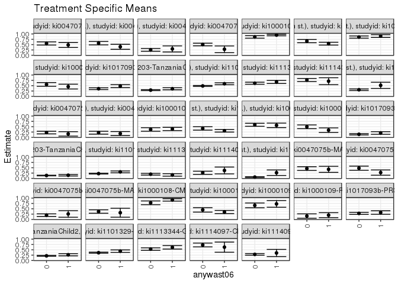

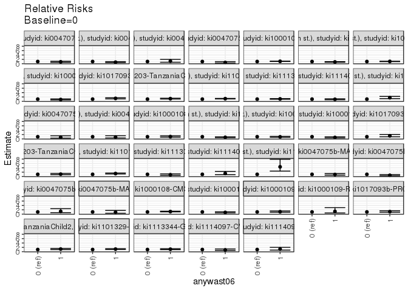

[figure not shown]

[figure not shown]

## Results Table

### Parameter: TSM

| agecat | studyid | country | intervention_level | baseline_level | estimate | ci_lower | ci_upper |
| --- | --- | --- | --- | --- | --- | --- | --- |
| 0-24 months (no birth st.) | ki0047075b-MAL-ED | BANGLADESH | 0 | NA | 0.5551979 | 0.4812009 | 0.6291949 |
| 0-24 months (no birth st.) | ki0047075b-MAL-ED | BANGLADESH | 1 | NA | 0.4846264 | 0.3668159 | 0.6024368 |
| 0-24 months (no birth st.) | ki0047075b-MAL-ED | INDIA | 0 | NA | 0.5693563 | 0.4883693 | 0.6503434 |
| 0-24 months (no birth st.) | ki0047075b-MAL-ED | INDIA | 1 | NA | 0.4001741 | 0.2807624 | 0.5195858 |
| 0-24 months (no birth st.) | ki0047075b-MAL-ED | NEPAL | 0 | NA | 0.2546303 | 0.1904519 | 0.3188087 |
| 0-24 months (no birth st.) | ki0047075b-MAL-ED | NEPAL | 1 | NA | 0.2989772 | 0.1573437 | 0.4406107 |
| 0-24 months (no birth st.) | ki0047075b-MAL-ED | SOUTH AFRICA | 0 | NA | 0.5054088 | 0.4435064 | 0.5673113 |
| 0-24 months (no birth st.) | ki0047075b-MAL-ED | SOUTH AFRICA | 1 | NA | 0.2832651 | 0.1270814 | 0.4394488 |
| 0-24 months (no birth st.) | ki1000108-CMC-V-BCS-2002 | INDIA | 0 | NA | 0.8613139 | 0.8033406 | 0.9192871 |
| 0-24 months (no birth st.) | ki1000108-CMC-V-BCS-2002 | INDIA | 1 | NA | 0.9487179 | 0.9140459 | 0.9833900 |
| 0-24 months (no birth st.) | ki1000108-IRC | INDIA | 0 | NA | 0.6660326 | 0.5879920 | 0.7440732 |
| 0-24 months (no birth st.) | ki1000108-IRC | INDIA | 1 | NA | 0.5455015 | 0.4799971 | 0.6110060 |
| 0-24 months (no birth st.) | ki1000109-EE | PAKISTAN | 0 | NA | 0.8554938 | 0.8042146 | 0.9067729 |
| 0-24 months (no birth st.) | ki1000109-EE | PAKISTAN | 1 | NA | 0.9018364 | 0.8370384 | 0.9666343 |
| 0-24 months (no birth st.) | ki1000109-ResPak | PAKISTAN | 0 | NA | 0.5573044 | 0.4709110 | 0.6436979 |
| 0-24 months (no birth st.) | ki1000109-ResPak | PAKISTAN | 1 | NA | 0.4564171 | 0.3439569 | 0.5688773 |
| 0-24 months (no birth st.) | ki1017093b-PROVIDE | BANGLADESH | 0 | NA | 0.3580727 | 0.3154932 | 0.4006522 |
| 0-24 months (no birth st.) | ki1017093b-PROVIDE | BANGLADESH | 1 | NA | 0.4800815 | 0.4089457 | 0.5512174 |
| 0-24 months (no birth st.) | ki1066203-TanzaniaChild2 | TANZANIA, UNITED REPUBLIC OF | 0 | NA | 0.2915767 | 0.2712983 | 0.3118550 |
| 0-24 months (no birth st.) | ki1066203-TanzaniaChild2 | TANZANIA, UNITED REPUBLIC OF | 1 | NA | 0.3553538 | 0.3076180 | 0.4030896 |
| 0-24 months (no birth st.) | ki1101329-Keneba | GAMBIA | 0 | NA | 0.4872037 | 0.4646971 | 0.5097104 |
| 0-24 months (no birth st.) | ki1101329-Keneba | GAMBIA | 1 | NA | 0.5904544 | 0.5446300 | 0.6362787 |
| 0-24 months (no birth st.) | ki1113344-GMS-Nepal | NEPAL | 0 | NA | 0.6146022 | 0.5650506 | 0.6641539 |
| 0-24 months (no birth st.) | ki1113344-GMS-Nepal | NEPAL | 1 | NA | 0.6766757 | 0.6051537 | 0.7481977 |
| 0-24 months (no birth st.) | ki1114097-CMIN | BANGLADESH | 0 | NA | 0.7664234 | 0.6953620 | 0.8374847 |
| 0-24 months (no birth st.) | ki1114097-CMIN | BANGLADESH | 1 | NA | 0.7096774 | 0.5494139 | 0.8699409 |
| 0-24 months (no birth st.) | ki1114097-CMIN | PERU | 0 | NA | 0.3096320 | 0.2730263 | 0.3462378 |
| 0-24 months (no birth st.) | ki1114097-CMIN | PERU | 1 | NA | 0.5153231 | 0.3695732 | 0.6610729 |
| 0-6 months (no birth st.) | ki0047075b-MAL-ED | BANGLADESH | 0 | NA | 0.2261905 | 0.1627815 | 0.2895994 |
| 0-6 months (no birth st.) | ki0047075b-MAL-ED | BANGLADESH | 1 | NA | 0.1632653 | 0.0595378 | 0.2669928 |
| 0-6 months (no birth st.) | ki0047075b-MAL-ED | INDIA | 0 | NA | 0.2208688 | 0.1528603 | 0.2888772 |
| 0-6 months (no birth st.) | ki0047075b-MAL-ED | INDIA | 1 | NA | 0.1781324 | 0.0844007 | 0.2718641 |
| 0-6 months (no birth st.) | ki1000108-CMC-V-BCS-2002 | INDIA | 0 | NA | 0.3718306 | 0.2908547 | 0.4528065 |
| 0-6 months (no birth st.) | ki1000108-CMC-V-BCS-2002 | INDIA | 1 | NA | 0.3939381 | 0.3171666 | 0.4707096 |
| 0-6 months (no birth st.) | ki1000108-IRC | INDIA | 0 | NA | 0.4198325 | 0.3395851 | 0.5000800 |
| 0-6 months (no birth st.) | ki1000108-IRC | INDIA | 1 | NA | 0.3095995 | 0.2492953 | 0.3699037 |
| 0-6 months (no birth st.) | ki1000109-EE | PAKISTAN | 0 | NA | 0.5911085 | 0.5200643 | 0.6621528 |
| 0-6 months (no birth st.) | ki1000109-EE | PAKISTAN | 1 | NA | 0.5639228 | 0.4578867 | 0.6699589 |
| 0-6 months (no birth st.) | ki1000109-ResPak | PAKISTAN | 0 | NA | 0.4956298 | 0.4084737 | 0.5827860 |
| 0-6 months (no birth st.) | ki1000109-ResPak | PAKISTAN | 1 | NA | 0.3375884 | 0.2312504 | 0.4439263 |
| 0-6 months (no birth st.) | ki1017093b-PROVIDE | BANGLADESH | 0 | NA | 0.1440875 | 0.1127116 | 0.1754633 |
| 0-6 months (no birth st.) | ki1017093b-PROVIDE | BANGLADESH | 1 | NA | 0.2057885 | 0.1446024 | 0.2669747 |
| 0-6 months (no birth st.) | ki1066203-TanzaniaChild2 | TANZANIA, UNITED REPUBLIC OF | 0 | NA | 0.1361501 | 0.1208574 | 0.1514428 |
| 0-6 months (no birth st.) | ki1066203-TanzaniaChild2 | TANZANIA, UNITED REPUBLIC OF | 1 | NA | 0.1477183 | 0.1118813 | 0.1835554 |
| 0-6 months (no birth st.) | ki1101329-Keneba | GAMBIA | 0 | NA | 0.2251809 | 0.2063420 | 0.2440199 |
| 0-6 months (no birth st.) | ki1101329-Keneba | GAMBIA | 1 | NA | 0.3060544 | 0.2632276 | 0.3488812 |
| 0-6 months (no birth st.) | ki1113344-GMS-Nepal | NEPAL | 0 | NA | 0.1975797 | 0.1572101 | 0.2379494 |
| 0-6 months (no birth st.) | ki1113344-GMS-Nepal | NEPAL | 1 | NA | 0.1630875 | 0.1067730 | 0.2194020 |
| 0-6 months (no birth st.) | ki1114097-CMIN | BANGLADESH | 0 | NA | 0.2635934 | 0.1896503 | 0.3375365 |
| 0-6 months (no birth st.) | ki1114097-CMIN | BANGLADESH | 1 | NA | 0.3732306 | 0.2123621 | 0.5340991 |
| 0-6 months (no birth st.) | ki1114097-CMIN | PERU | 0 | NA | 0.0603323 | 0.0414805 | 0.0791842 |
| 0-6 months (no birth st.) | ki1114097-CMIN | PERU | 1 | NA | 0.2675568 | 0.1379624 | 0.3971513 |
| 6-24 months | ki0047075b-MAL-ED | BANGLADESH | 0 | NA | 0.4619393 | 0.3742522 | 0.5496264 |
| 6-24 months | ki0047075b-MAL-ED | BANGLADESH | 1 | NA | 0.4248713 | 0.2829458 | 0.5667968 |
| 6-24 months | ki0047075b-MAL-ED | INDIA | 0 | NA | 0.4807872 | 0.3844591 | 0.5771154 |
| 6-24 months | ki0047075b-MAL-ED | INDIA | 1 | NA | 0.2744808 | 0.1515772 | 0.3973845 |
| 6-24 months | ki0047075b-MAL-ED | NEPAL | 0 | NA | 0.2012195 | 0.1397030 | 0.2627360 |
| 6-24 months | ki0047075b-MAL-ED | NEPAL | 1 | NA | 0.2580645 | 0.1036348 | 0.4124942 |
| 6-24 months | ki0047075b-MAL-ED | SOUTH AFRICA | 0 | NA | 0.3714286 | 0.2911372 | 0.4517200 |
| 6-24 months | ki0047075b-MAL-ED | SOUTH AFRICA | 1 | NA | 0.3157895 | 0.1061201 | 0.5254589 |
| 6-24 months | ki1000108-CMC-V-BCS-2002 | INDIA | 0 | NA | 0.7790698 | 0.6911437 | 0.8669958 |
| 6-24 months | ki1000108-CMC-V-BCS-2002 | INDIA | 1 | NA | 0.9157895 | 0.8597918 | 0.9717872 |
| 6-24 months | ki1000108-IRC | INDIA | 0 | NA | 0.4481976 | 0.3447476 | 0.5516475 |
| 6-24 months | ki1000108-IRC | INDIA | 1 | NA | 0.3490238 | 0.2744418 | 0.4236057 |
| 6-24 months | ki1000109-EE | PAKISTAN | 0 | NA | 0.6599003 | 0.5482866 | 0.7715140 |
| 6-24 months | ki1000109-EE | PAKISTAN | 1 | NA | 0.7286526 | 0.5711236 | 0.8861816 |
| 6-24 months | ki1000109-ResPak | PAKISTAN | 0 | NA | 0.1600000 | 0.0578448 | 0.2621552 |
| 6-24 months | ki1000109-ResPak | PAKISTAN | 1 | NA | 0.2000000 | 0.0825103 | 0.3174897 |
| 6-24 months | ki1017093b-PROVIDE | BANGLADESH | 0 | NA | 0.2840366 | 0.2370129 | 0.3310602 |
| 6-24 months | ki1017093b-PROVIDE | BANGLADESH | 1 | NA | 0.3238552 | 0.2416348 | 0.4060757 |
| 6-24 months | ki1066203-TanzaniaChild2 | TANZANIA, UNITED REPUBLIC OF | 0 | NA | 0.2180943 | 0.1962344 | 0.2399543 |
| 6-24 months | ki1066203-TanzaniaChild2 | TANZANIA, UNITED REPUBLIC OF | 1 | NA | 0.2682369 | 0.2161751 | 0.3202986 |
| 6-24 months | ki1101329-Keneba | GAMBIA | 0 | NA | 0.3642036 | 0.3386054 | 0.3898017 |
| 6-24 months | ki1101329-Keneba | GAMBIA | 1 | NA | 0.4378424 | 0.3803499 | 0.4953349 |
| 6-24 months | ki1113344-GMS-Nepal | NEPAL | 0 | NA | 0.5344850 | 0.4770176 | 0.5919525 |
| 6-24 months | ki1113344-GMS-Nepal | NEPAL | 1 | NA | 0.6176266 | 0.5359074 | 0.6993458 |
| 6-24 months | ki1114097-CMIN | BANGLADESH | 0 | NA | 0.7263158 | 0.6362543 | 0.8163773 |
| 6-24 months | ki1114097-CMIN | BANGLADESH | 1 | NA | 0.6250000 | 0.3867083 | 0.8632917 |
| 6-24 months | ki1114097-CMIN | PERU | 0 | NA | 0.2855384 | 0.2472732 | 0.3238037 |
| 6-24 months | ki1114097-CMIN | PERU | 1 | NA | 0.3524953 | 0.1843592 | 0.5206314 |

### Parameter: E(Y)

| agecat | studyid | country | intervention_level | baseline_level | estimate | ci_lower | ci_upper |
| --- | --- | --- | --- | --- | --- | --- | --- |
| 0-24 months (no birth st.) | ki0047075b-MAL-ED | BANGLADESH | NA | NA | 0.5207373 | 0.4541154 | 0.5873593 |
| 0-24 months (no birth st.) | ki0047075b-MAL-ED | INDIA | NA | NA | 0.5167464 | 0.4488350 | 0.5846578 |
| 0-24 months (no birth st.) | ki0047075b-MAL-ED | NEPAL | NA | NA | 0.2594340 | 0.2002911 | 0.3185768 |
| 0-24 months (no birth st.) | ki0047075b-MAL-ED | SOUTH AFRICA | NA | NA | 0.4892857 | 0.4306292 | 0.5479422 |
| 0-24 months (no birth st.) | ki1000108-CMC-V-BCS-2002 | INDIA | NA | NA | 0.9078498 | 0.8746748 | 0.9410249 |
| 0-24 months (no birth st.) | ki1000108-IRC | INDIA | NA | NA | 0.5916667 | 0.5408218 | 0.6425115 |
| 0-24 months (no birth st.) | ki1000109-EE | PAKISTAN | NA | NA | 0.8674699 | 0.8252704 | 0.9096693 |
| 0-24 months (no birth st.) | ki1000109-ResPak | PAKISTAN | NA | NA | 0.5198020 | 0.4507336 | 0.5888704 |
| 0-24 months (no birth st.) | ki1017093b-PROVIDE | BANGLADESH | NA | NA | 0.3753943 | 0.3376725 | 0.4131162 |
| 0-24 months (no birth st.) | ki1066203-TanzaniaChild2 | TANZANIA, UNITED REPUBLIC OF | NA | NA | 0.2988814 | 0.2798990 | 0.3178639 |
| 0-24 months (no birth st.) | ki1101329-Keneba | GAMBIA | NA | NA | 0.5044763 | 0.4837388 | 0.5252138 |
| 0-24 months (no birth st.) | ki1113344-GMS-Nepal | NEPAL | NA | NA | 0.6336449 | 0.5927799 | 0.6745099 |
| 0-24 months (no birth st.) | ki1114097-CMIN | BANGLADESH | NA | NA | 0.7559524 | 0.6908084 | 0.8210964 |
| 0-24 months (no birth st.) | ki1114097-CMIN | PERU | NA | NA | 0.3237082 | 0.2879308 | 0.3594857 |
| 0-6 months (no birth st.) | ki0047075b-MAL-ED | BANGLADESH | NA | NA | 0.2119816 | 0.1574763 | 0.2664868 |
| 0-6 months (no birth st.) | ki0047075b-MAL-ED | INDIA | NA | NA | 0.2105263 | 0.1551227 | 0.2659300 |
| 0-6 months (no birth st.) | ki1000108-CMC-V-BCS-2002 | INDIA | NA | NA | 0.3835616 | 0.3276935 | 0.4394298 |
| 0-6 months (no birth st.) | ki1000108-IRC | INDIA | NA | NA | 0.3444444 | 0.2952897 | 0.3935992 |
| 0-6 months (no birth st.) | ki1000109-EE | PAKISTAN | NA | NA | 0.6024096 | 0.5415000 | 0.6633193 |
| 0-6 months (no birth st.) | ki1000109-ResPak | PAKISTAN | NA | NA | 0.4356436 | 0.3670959 | 0.5041912 |
| 0-6 months (no birth st.) | ki1017093b-PROVIDE | BANGLADESH | NA | NA | 0.1593060 | 0.1307970 | 0.1878149 |
| 0-6 months (no birth st.) | ki1066203-TanzaniaChild2 | TANZANIA, UNITED REPUBLIC OF | NA | NA | 0.1369128 | 0.1226581 | 0.1511674 |
| 0-6 months (no birth st.) | ki1101329-Keneba | GAMBIA | NA | NA | 0.2412713 | 0.2235253 | 0.2590172 |
| 0-6 months (no birth st.) | ki1113344-GMS-Nepal | NEPAL | NA | NA | 0.1869159 | 0.1538509 | 0.2199809 |
| 0-6 months (no birth st.) | ki1114097-CMIN | BANGLADESH | NA | NA | 0.2857143 | 0.2171983 | 0.3542303 |
| 0-6 months (no birth st.) | ki1114097-CMIN | PERU | NA | NA | 0.0744681 | 0.0543935 | 0.0945427 |
| 6-24 months | ki0047075b-MAL-ED | BANGLADESH | NA | NA | 0.4213836 | 0.3443902 | 0.4983771 |
| 6-24 months | ki0047075b-MAL-ED | INDIA | NA | NA | 0.4129032 | 0.3351414 | 0.4906651 |
| 6-24 months | ki0047075b-MAL-ED | NEPAL | NA | NA | 0.2102564 | 0.1529155 | 0.2675974 |
| 6-24 months | ki0047075b-MAL-ED | SOUTH AFRICA | NA | NA | 0.3647799 | 0.2897219 | 0.4398379 |
| 6-24 months | ki1000108-CMC-V-BCS-2002 | INDIA | NA | NA | 0.8508287 | 0.7987841 | 0.9028733 |
| 6-24 months | ki1000108-IRC | INDIA | NA | NA | 0.3771186 | 0.3151523 | 0.4390850 |
| 6-24 months | ki1000109-EE | PAKISTAN | NA | NA | 0.6804124 | 0.5871313 | 0.7736934 |
| 6-24 months | ki1000109-ResPak | PAKISTAN | NA | NA | 0.1789474 | 0.1014597 | 0.2564350 |
| 6-24 months | ki1017093b-PROVIDE | BANGLADESH | NA | NA | 0.2997812 | 0.2577294 | 0.3418330 |
| 6-24 months | ki1066203-TanzaniaChild2 | TANZANIA, UNITED REPUBLIC OF | NA | NA | 0.2259675 | 0.2054816 | 0.2464534 |
| 6-24 months | ki1101329-Keneba | GAMBIA | NA | NA | 0.3752393 | 0.3512585 | 0.3992201 |
| 6-24 months | ki1113344-GMS-Nepal | NEPAL | NA | NA | 0.5610329 | 0.5138522 | 0.6082135 |
| 6-24 months | ki1114097-CMIN | BANGLADESH | NA | NA | 0.7117117 | 0.6270636 | 0.7963598 |
| 6-24 months | ki1114097-CMIN | PERU | NA | NA | 0.2892416 | 0.2518881 | 0.3265951 |

### Parameter: RR

| agecat | studyid | country | intervention_level | baseline_level | estimate | ci_lower | ci_upper |
| --- | --- | --- | --- | --- | --- | --- | --- |
| 0-24 months (no birth st.) | ki0047075b-MAL-ED | BANGLADESH | 0 | 0 | 1.0000000 | 1.0000000 | 1.0000000 |
| 0-24 months (no birth st.) | ki0047075b-MAL-ED | BANGLADESH | 1 | 0 | 0.8728894 | 0.6624401 | 1.1501960 |
| 0-24 months (no birth st.) | ki0047075b-MAL-ED | INDIA | 0 | 0 | 1.0000000 | 1.0000000 | 1.0000000 |
| 0-24 months (no birth st.) | ki0047075b-MAL-ED | INDIA | 1 | 0 | 0.7028535 | 0.5050984 | 0.9780333 |
| 0-24 months (no birth st.) | ki0047075b-MAL-ED | NEPAL | 0 | 0 | 1.0000000 | 1.0000000 | 1.0000000 |
| 0-24 months (no birth st.) | ki0047075b-MAL-ED | NEPAL | 1 | 0 | 1.1741616 | 0.6866580 | 2.0077762 |
| 0-24 months (no birth st.) | ki0047075b-MAL-ED | SOUTH AFRICA | 0 | 0 | 1.0000000 | 1.0000000 | 1.0000000 |
| 0-24 months (no birth st.) | ki0047075b-MAL-ED | SOUTH AFRICA | 1 | 0 | 0.5604674 | 0.3186391 | 0.9858291 |
| 0-24 months (no birth st.) | ki1000108-CMC-V-BCS-2002 | INDIA | 0 | 0 | 1.0000000 | 1.0000000 | 1.0000000 |
| 0-24 months (no birth st.) | ki1000108-CMC-V-BCS-2002 | INDIA | 1 | 0 | 1.1014776 | 1.0202655 | 1.1891541 |
| 0-24 months (no birth st.) | ki1000108-IRC | INDIA | 0 | 0 | 1.0000000 | 1.0000000 | 1.0000000 |
| 0-24 months (no birth st.) | ki1000108-IRC | INDIA | 1 | 0 | 0.8190313 | 0.6930485 | 0.9679153 |
| 0-24 months (no birth st.) | ki1000109-EE | PAKISTAN | 0 | 0 | 1.0000000 | 1.0000000 | 1.0000000 |
| 0-24 months (no birth st.) | ki1000109-EE | PAKISTAN | 1 | 0 | 1.0541706 | 0.9608295 | 1.1565794 |
| 0-24 months (no birth st.) | ki1000109-ResPak | PAKISTAN | 0 | 0 | 1.0000000 | 1.0000000 | 1.0000000 |
| 0-24 months (no birth st.) | ki1000109-ResPak | PAKISTAN | 1 | 0 | 0.8189726 | 0.6126535 | 1.0947723 |
| 0-24 months (no birth st.) | ki1017093b-PROVIDE | BANGLADESH | 0 | 0 | 1.0000000 | 1.0000000 | 1.0000000 |
| 0-24 months (no birth st.) | ki1017093b-PROVIDE | BANGLADESH | 1 | 0 | 1.3407376 | 1.1092298 | 1.6205635 |
| 0-24 months (no birth st.) | ki1066203-TanzaniaChild2 | TANZANIA, UNITED REPUBLIC OF | 0 | 0 | 1.0000000 | 1.0000000 | 1.0000000 |
| 0-24 months (no birth st.) | ki1066203-TanzaniaChild2 | TANZANIA, UNITED REPUBLIC OF | 1 | 0 | 1.2187318 | 1.0478230 | 1.4175173 |
| 0-24 months (no birth st.) | ki1101329-Keneba | GAMBIA | 0 | 0 | 1.0000000 | 1.0000000 | 1.0000000 |
| 0-24 months (no birth st.) | ki1101329-Keneba | GAMBIA | 1 | 0 | 1.2119249 | 1.1078529 | 1.3257735 |
| 0-24 months (no birth st.) | ki1113344-GMS-Nepal | NEPAL | 0 | 0 | 1.0000000 | 1.0000000 | 1.0000000 |
| 0-24 months (no birth st.) | ki1113344-GMS-Nepal | NEPAL | 1 | 0 | 1.1009978 | 0.9639924 | 1.2574749 |
| 0-24 months (no birth st.) | ki1114097-CMIN | BANGLADESH | 0 | 0 | 1.0000000 | 1.0000000 | 1.0000000 |
| 0-24 months (no birth st.) | ki1114097-CMIN | BANGLADESH | 1 | 0 | 0.9259601 | 0.7253921 | 1.1819842 |
| 0-24 months (no birth st.) | ki1114097-CMIN | PERU | 0 | 0 | 1.0000000 | 1.0000000 | 1.0000000 |
| 0-24 months (no birth st.) | ki1114097-CMIN | PERU | 1 | 0 | 1.6643079 | 1.2251444 | 2.2608933 |
| 0-6 months (no birth st.) | ki0047075b-MAL-ED | BANGLADESH | 0 | 0 | 1.0000000 | 1.0000000 | 1.0000000 |
| 0-6 months (no birth st.) | ki0047075b-MAL-ED | BANGLADESH | 1 | 0 | 0.7218045 | 0.3604397 | 1.4454618 |
| 0-6 months (no birth st.) | ki0047075b-MAL-ED | INDIA | 0 | 0 | 1.0000000 | 1.0000000 | 1.0000000 |
| 0-6 months (no birth st.) | ki0047075b-MAL-ED | INDIA | 1 | 0 | 0.8065079 | 0.4383527 | 1.4838622 |
| 0-6 months (no birth st.) | ki1000108-CMC-V-BCS-2002 | INDIA | 0 | 0 | 1.0000000 | 1.0000000 | 1.0000000 |
| 0-6 months (no birth st.) | ki1000108-CMC-V-BCS-2002 | INDIA | 1 | 0 | 1.0594559 | 0.7915515 | 1.4180338 |
| 0-6 months (no birth st.) | ki1000108-IRC | INDIA | 0 | 0 | 1.0000000 | 1.0000000 | 1.0000000 |
| 0-6 months (no birth st.) | ki1000108-IRC | INDIA | 1 | 0 | 0.7374356 | 0.5616971 | 0.9681577 |
| 0-6 months (no birth st.) | ki1000109-EE | PAKISTAN | 0 | 0 | 1.0000000 | 1.0000000 | 1.0000000 |
| 0-6 months (no birth st.) | ki1000109-EE | PAKISTAN | 1 | 0 | 0.9540089 | 0.7637570 | 1.1916525 |
| 0-6 months (no birth st.) | ki1000109-ResPak | PAKISTAN | 0 | 0 | 1.0000000 | 1.0000000 | 1.0000000 |
| 0-6 months (no birth st.) | ki1000109-ResPak | PAKISTAN | 1 | 0 | 0.6811300 | 0.4750565 | 0.9765957 |
| 0-6 months (no birth st.) | ki1017093b-PROVIDE | BANGLADESH | 0 | 0 | 1.0000000 | 1.0000000 | 1.0000000 |
| 0-6 months (no birth st.) | ki1017093b-PROVIDE | BANGLADESH | 1 | 0 | 1.4282196 | 0.9903128 | 2.0597645 |
| 0-6 months (no birth st.) | ki1066203-TanzaniaChild2 | TANZANIA, UNITED REPUBLIC OF | 0 | 0 | 1.0000000 | 1.0000000 | 1.0000000 |
| 0-6 months (no birth st.) | ki1066203-TanzaniaChild2 | TANZANIA, UNITED REPUBLIC OF | 1 | 0 | 1.0849667 | 0.8305770 | 1.4172711 |
| 0-6 months (no birth st.) | ki1101329-Keneba | GAMBIA | 0 | 0 | 1.0000000 | 1.0000000 | 1.0000000 |
| 0-6 months (no birth st.) | ki1101329-Keneba | GAMBIA | 1 | 0 | 1.3591488 | 1.1553801 | 1.5988551 |
| 0-6 months (no birth st.) | ki1113344-GMS-Nepal | NEPAL | 0 | 0 | 1.0000000 | 1.0000000 | 1.0000000 |
| 0-6 months (no birth st.) | ki1113344-GMS-Nepal | NEPAL | 1 | 0 | 0.8254260 | 0.5532635 | 1.2314713 |
| 0-6 months (no birth st.) | ki1114097-CMIN | BANGLADESH | 0 | 0 | 1.0000000 | 1.0000000 | 1.0000000 |
| 0-6 months (no birth st.) | ki1114097-CMIN | BANGLADESH | 1 | 0 | 1.4159331 | 0.8502263 | 2.3580385 |
| 0-6 months (no birth st.) | ki1114097-CMIN | PERU | 0 | 0 | 1.0000000 | 1.0000000 | 1.0000000 |
| 0-6 months (no birth st.) | ki1114097-CMIN | PERU | 1 | 0 | 4.4347188 | 2.4924872 | 7.8904039 |
| 6-24 months | ki0047075b-MAL-ED | BANGLADESH | 0 | 0 | 1.0000000 | 1.0000000 | 1.0000000 |
| 6-24 months | ki0047075b-MAL-ED | BANGLADESH | 1 | 0 | 0.9197558 | 0.6256790 | 1.3520522 |
| 6-24 months | ki0047075b-MAL-ED | INDIA | 0 | 0 | 1.0000000 | 1.0000000 | 1.0000000 |
| 6-24 months | ki0047075b-MAL-ED | INDIA | 1 | 0 | 0.5708988 | 0.3495502 | 0.9324139 |
| 6-24 months | ki0047075b-MAL-ED | NEPAL | 0 | 0 | 1.0000000 | 1.0000000 | 1.0000000 |
| 6-24 months | ki0047075b-MAL-ED | NEPAL | 1 | 0 | 1.2825024 | 0.6549659 | 2.5112951 |
| 6-24 months | ki0047075b-MAL-ED | SOUTH AFRICA | 0 | 0 | 1.0000000 | 1.0000000 | 1.0000000 |
| 6-24 months | ki0047075b-MAL-ED | SOUTH AFRICA | 1 | 0 | 0.8502024 | 0.4229346 | 1.7091157 |
| 6-24 months | ki1000108-CMC-V-BCS-2002 | INDIA | 0 | 0 | 1.0000000 | 1.0000000 | 1.0000000 |
| 6-24 months | ki1000108-CMC-V-BCS-2002 | INDIA | 1 | 0 | 1.1754910 | 1.0338870 | 1.3364894 |
| 6-24 months | ki1000108-IRC | INDIA | 0 | 0 | 1.0000000 | 1.0000000 | 1.0000000 |
| 6-24 months | ki1000108-IRC | INDIA | 1 | 0 | 0.7787275 | 0.5689820 | 1.0657922 |
| 6-24 months | ki1000109-EE | PAKISTAN | 0 | 0 | 1.0000000 | 1.0000000 | 1.0000000 |
| 6-24 months | ki1000109-EE | PAKISTAN | 1 | 0 | 1.1041858 | 0.8417728 | 1.4484030 |
| 6-24 months | ki1000109-ResPak | PAKISTAN | 0 | 0 | 1.0000000 | 1.0000000 | 1.0000000 |
| 6-24 months | ki1000109-ResPak | PAKISTAN | 1 | 0 | 1.2500000 | 0.5249448 | 2.9765036 |
| 6-24 months | ki1017093b-PROVIDE | BANGLADESH | 0 | 0 | 1.0000000 | 1.0000000 | 1.0000000 |
| 6-24 months | ki1017093b-PROVIDE | BANGLADESH | 1 | 0 | 1.1401884 | 0.8421227 | 1.5437532 |
| 6-24 months | ki1066203-TanzaniaChild2 | TANZANIA, UNITED REPUBLIC OF | 0 | 0 | 1.0000000 | 1.0000000 | 1.0000000 |
| 6-24 months | ki1066203-TanzaniaChild2 | TANZANIA, UNITED REPUBLIC OF | 1 | 0 | 1.2299121 | 0.9885784 | 1.5301608 |
| 6-24 months | ki1101329-Keneba | GAMBIA | 0 | 0 | 1.0000000 | 1.0000000 | 1.0000000 |
| 6-24 months | ki1101329-Keneba | GAMBIA | 1 | 0 | 1.2021914 | 1.0366632 | 1.3941501 |
| 6-24 months | ki1113344-GMS-Nepal | NEPAL | 0 | 0 | 1.0000000 | 1.0000000 | 1.0000000 |
| 6-24 months | ki1113344-GMS-Nepal | NEPAL | 1 | 0 | 1.1555546 | 0.9744475 | 1.3703217 |
| 6-24 months | ki1114097-CMIN | BANGLADESH | 0 | 0 | 1.0000000 | 1.0000000 | 1.0000000 |
| 6-24 months | ki1114097-CMIN | BANGLADESH | 1 | 0 | 0.8605072 | 0.5762828 | 1.2849121 |
| 6-24 months | ki1114097-CMIN | PERU | 0 | 0 | 1.0000000 | 1.0000000 | 1.0000000 |
| 6-24 months | ki1114097-CMIN | PERU | 1 | 0 | 1.2344933 | 0.7522439 | 2.0259036 |

### Parameter: PAR

| agecat | studyid | country | intervention_level | baseline_level | estimate | ci_lower | ci_upper |
| --- | --- | --- | --- | --- | --- | --- | --- |
| 0-24 months (no birth st.) | ki0047075b-MAL-ED | BANGLADESH | 0 | NA | -0.0344606 | -0.0705313 | 0.0016102 |
| 0-24 months (no birth st.) | ki0047075b-MAL-ED | INDIA | 0 | NA | -0.0526099 | -0.0986991 | -0.0065207 |
| 0-24 months (no birth st.) | ki0047075b-MAL-ED | NEPAL | 0 | NA | 0.0048036 | -0.0221681 | 0.0317754 |
| 0-24 months (no birth st.) | ki0047075b-MAL-ED | SOUTH AFRICA | 0 | NA | -0.0161231 | -0.0360281 | 0.0037819 |
| 0-24 months (no birth st.) | ki1000108-CMC-V-BCS-2002 | INDIA | 0 | NA | 0.0465360 | 0.0102244 | 0.0828475 |
| 0-24 months (no birth st.) | ki1000108-IRC | INDIA | 0 | NA | -0.0743659 | -0.1372250 | -0.0115068 |
| 0-24 months (no birth st.) | ki1000109-EE | PAKISTAN | 0 | NA | 0.0119761 | -0.0134866 | 0.0374388 |
| 0-24 months (no birth st.) | ki1000109-ResPak | PAKISTAN | 0 | NA | -0.0375025 | -0.0904571 | 0.0154522 |
| 0-24 months (no birth st.) | ki1017093b-PROVIDE | BANGLADESH | 0 | NA | 0.0173216 | -0.0046615 | 0.0393047 |
| 0-24 months (no birth st.) | ki1066203-TanzaniaChild2 | TANZANIA, UNITED REPUBLIC OF | 0 | NA | 0.0073048 | -0.0006812 | 0.0152908 |
| 0-24 months (no birth st.) | ki1101329-Keneba | GAMBIA | 0 | NA | 0.0172725 | 0.0082542 | 0.0262908 |
| 0-24 months (no birth st.) | ki1113344-GMS-Nepal | NEPAL | 0 | NA | 0.0190426 | -0.0077505 | 0.0458358 |
| 0-24 months (no birth st.) | ki1114097-CMIN | BANGLADESH | 0 | NA | -0.0104710 | -0.0429919 | 0.0220500 |
| 0-24 months (no birth st.) | ki1114097-CMIN | PERU | 0 | NA | 0.0140762 | 0.0031603 | 0.0249920 |
| 0-6 months (no birth st.) | ki0047075b-MAL-ED | BANGLADESH | 0 | NA | -0.0142089 | -0.0418843 | 0.0134665 |
| 0-6 months (no birth st.) | ki0047075b-MAL-ED | INDIA | 0 | NA | -0.0103425 | -0.0466411 | 0.0259562 |
| 0-6 months (no birth st.) | ki1000108-CMC-V-BCS-2002 | INDIA | 0 | NA | 0.0117310 | -0.0473680 | 0.0708301 |
| 0-6 months (no birth st.) | ki1000108-IRC | INDIA | 0 | NA | -0.0753881 | -0.1371109 | -0.0136653 |
| 0-6 months (no birth st.) | ki1000109-EE | PAKISTAN | 0 | NA | 0.0113011 | -0.0270832 | 0.0496854 |
| 0-6 months (no birth st.) | ki1000109-ResPak | PAKISTAN | 0 | NA | -0.0599862 | -0.1123074 | -0.0076651 |
| 0-6 months (no birth st.) | ki1017093b-PROVIDE | BANGLADESH | 0 | NA | 0.0152185 | -0.0023173 | 0.0327543 |
| 0-6 months (no birth st.) | ki1066203-TanzaniaChild2 | TANZANIA, UNITED REPUBLIC OF | 0 | NA | 0.0007626 | -0.0051410 | 0.0066663 |
| 0-6 months (no birth st.) | ki1101329-Keneba | GAMBIA | 0 | NA | 0.0160903 | 0.0075558 | 0.0246248 |
| 0-6 months (no birth st.) | ki1113344-GMS-Nepal | NEPAL | 0 | NA | -0.0106639 | -0.0319041 | 0.0105764 |
| 0-6 months (no birth st.) | ki1114097-CMIN | BANGLADESH | 0 | NA | 0.0221209 | -0.0125648 | 0.0568066 |
| 0-6 months (no birth st.) | ki1114097-CMIN | PERU | 0 | NA | 0.0141358 | 0.0043765 | 0.0238950 |
| 6-24 months | ki0047075b-MAL-ED | BANGLADESH | 0 | NA | -0.0405556 | -0.0833106 | 0.0021993 |
| 6-24 months | ki0047075b-MAL-ED | INDIA | 0 | NA | -0.0678840 | -0.1215001 | -0.0142679 |
| 6-24 months | ki0047075b-MAL-ED | NEPAL | 0 | NA | 0.0090369 | -0.0175510 | 0.0356248 |
| 6-24 months | ki0047075b-MAL-ED | SOUTH AFRICA | 0 | NA | -0.0066487 | -0.0336250 | 0.0203276 |
| 6-24 months | ki1000108-CMC-V-BCS-2002 | INDIA | 0 | NA | 0.0717590 | 0.0161437 | 0.1273742 |
| 6-24 months | ki1000108-IRC | INDIA | 0 | NA | -0.0710789 | -0.1539732 | 0.0118154 |
| 6-24 months | ki1000109-EE | PAKISTAN | 0 | NA | 0.0205120 | -0.0375245 | 0.0785486 |
| 6-24 months | ki1000109-ResPak | PAKISTAN | 0 | NA | 0.0189474 | -0.0549112 | 0.0928059 |
| 6-24 months | ki1017093b-PROVIDE | BANGLADESH | 0 | NA | 0.0157446 | -0.0081631 | 0.0396523 |
| 6-24 months | ki1066203-TanzaniaChild2 | TANZANIA, UNITED REPUBLIC OF | 0 | NA | 0.0078732 | -0.0011271 | 0.0168736 |
| 6-24 months | ki1101329-Keneba | GAMBIA | 0 | NA | 0.0110357 | 0.0009593 | 0.0211122 |
| 6-24 months | ki1113344-GMS-Nepal | NEPAL | 0 | NA | 0.0265478 | -0.0055612 | 0.0586569 |
| 6-24 months | ki1114097-CMIN | BANGLADESH | 0 | NA | -0.0146041 | -0.0519211 | 0.0227130 |
| 6-24 months | ki1114097-CMIN | PERU | 0 | NA | 0.0037032 | -0.0058138 | 0.0132202 |

### Parameter: PAF

| agecat | studyid | country | intervention_level | baseline_level | estimate | ci_lower | ci_upper |
| --- | --- | --- | --- | --- | --- | --- | --- |
| 0-24 months (no birth st.) | ki0047075b-MAL-ED | BANGLADESH | 0 | NA | -0.0661765 | -0.1387864 | 0.0018038 |
| 0-24 months (no birth st.) | ki0047075b-MAL-ED | INDIA | 0 | NA | -0.1018099 | -0.1961990 | -0.0148689 |
| 0-24 months (no birth st.) | ki0047075b-MAL-ED | NEPAL | 0 | NA | 0.0185158 | -0.0910924 | 0.1171131 |
| 0-24 months (no birth st.) | ki0047075b-MAL-ED | SOUTH AFRICA | 0 | NA | -0.0329523 | -0.0746535 | 0.0071307 |
| 0-24 months (no birth st.) | ki1000108-CMC-V-BCS-2002 | INDIA | 0 | NA | 0.0512595 | 0.0096051 | 0.0911621 |
| 0-24 months (no birth st.) | ki1000108-IRC | INDIA | 0 | NA | -0.1256889 | -0.2385285 | -0.0231298 |
| 0-24 months (no birth st.) | ki1000109-EE | PAKISTAN | 0 | NA | 0.0138058 | -0.0160606 | 0.0427942 |
| 0-24 months (no birth st.) | ki1000109-ResPak | PAKISTAN | 0 | NA | -0.0721476 | -0.1796733 | 0.0255772 |
| 0-24 months (no birth st.) | ki1017093b-PROVIDE | BANGLADESH | 0 | NA | 0.0461425 | -0.0141706 | 0.1028687 |
| 0-24 months (no birth st.) | ki1066203-TanzaniaChild2 | TANZANIA, UNITED REPUBLIC OF | 0 | NA | 0.0244404 | -0.0026271 | 0.0507770 |
| 0-24 months (no birth st.) | ki1101329-Keneba | GAMBIA | 0 | NA | 0.0342385 | 0.0161576 | 0.0519872 |
| 0-24 months (no birth st.) | ki1113344-GMS-Nepal | NEPAL | 0 | NA | 0.0300525 | -0.0132756 | 0.0715280 |
| 0-24 months (no birth st.) | ki1114097-CMIN | BANGLADESH | 0 | NA | -0.0138514 | -0.0578881 | 0.0283523 |
| 0-24 months (no birth st.) | ki1114097-CMIN | PERU | 0 | NA | 0.0434841 | 0.0091840 | 0.0765968 |
| 0-6 months (no birth st.) | ki0047075b-MAL-ED | BANGLADESH | 0 | NA | -0.0670290 | -0.2053590 | 0.0554259 |
| 0-6 months (no birth st.) | ki0047075b-MAL-ED | INDIA | 0 | NA | -0.0491267 | -0.2361916 | 0.1096309 |
| 0-6 months (no birth st.) | ki1000108-CMC-V-BCS-2002 | INDIA | 0 | NA | 0.0305845 | -0.1364459 | 0.1730654 |
| 0-6 months (no birth st.) | ki1000108-IRC | INDIA | 0 | NA | -0.2188687 | -0.4137776 | -0.0508307 |
| 0-6 months (no birth st.) | ki1000109-EE | PAKISTAN | 0 | NA | 0.0187598 | -0.0470436 | 0.0804278 |
| 0-6 months (no birth st.) | ki1000109-ResPak | PAKISTAN | 0 | NA | -0.1376957 | -0.2659911 | -0.0224018 |
| 0-6 months (no birth st.) | ki1017093b-PROVIDE | BANGLADESH | 0 | NA | 0.0955302 | -0.0203966 | 0.1982866 |
| 0-6 months (no birth st.) | ki1066203-TanzaniaChild2 | TANZANIA, UNITED REPUBLIC OF | 0 | NA | 0.0055702 | -0.0384873 | 0.0477586 |
| 0-6 months (no birth st.) | ki1101329-Keneba | GAMBIA | 0 | NA | 0.0666898 | 0.0308376 | 0.1012157 |
| 0-6 months (no birth st.) | ki1113344-GMS-Nepal | NEPAL | 0 | NA | -0.0570517 | -0.1768366 | 0.0505409 |
| 0-6 months (no birth st.) | ki1114097-CMIN | BANGLADESH | 0 | NA | 0.0774231 | -0.0520298 | 0.1909467 |
| 0-6 months (no birth st.) | ki1114097-CMIN | PERU | 0 | NA | 0.1898233 | 0.0580637 | 0.3031522 |
| 6-24 months | ki0047075b-MAL-ED | BANGLADESH | 0 | NA | -0.0962440 | -0.2044048 | 0.0022036 |
| 6-24 months | ki0047075b-MAL-ED | INDIA | 0 | NA | -0.1644066 | -0.3043970 | -0.0394402 |
| 6-24 months | ki0047075b-MAL-ED | NEPAL | 0 | NA | 0.0429804 | -0.0919047 | 0.1612028 |
| 6-24 months | ki0047075b-MAL-ED | SOUTH AFRICA | 0 | NA | -0.0182266 | -0.0949479 | 0.0531189 |
| 6-24 months | ki1000108-CMC-V-BCS-2002 | INDIA | 0 | NA | 0.0843401 | 0.0145466 | 0.1491905 |
| 6-24 months | ki1000108-IRC | INDIA | 0 | NA | -0.1884789 | -0.4325769 | 0.0140270 |
| 6-24 months | ki1000109-EE | PAKISTAN | 0 | NA | 0.0301465 | -0.0592835 | 0.1120264 |
| 6-24 months | ki1000109-ResPak | PAKISTAN | 0 | NA | 0.1058824 | -0.4161708 | 0.4354873 |
| 6-24 months | ki1017093b-PROVIDE | BANGLADESH | 0 | NA | 0.0525203 | -0.0305399 | 0.1288860 |
| 6-24 months | ki1066203-TanzaniaChild2 | TANZANIA, UNITED REPUBLIC OF | 0 | NA | 0.0348422 | -0.0057481 | 0.0737944 |
| 6-24 months | ki1101329-Keneba | GAMBIA | 0 | NA | 0.0294098 | 0.0021993 | 0.0558783 |
| 6-24 months | ki1113344-GMS-Nepal | NEPAL | 0 | NA | 0.0473196 | -0.0118765 | 0.1030526 |
| 6-24 months | ki1114097-CMIN | BANGLADESH | 0 | NA | -0.0205197 | -0.0745638 | 0.0308064 |
| 6-24 months | ki1114097-CMIN | PERU | 0 | NA | 0.0128031 | -0.0206456 | 0.0451556 |